# Incidence and Prevalence

### Interval Options

Below are options of what the text string inputs for `interval=` can be and we show how the plot labels can change when using the different options.

- integer of number of days: Interpreted as ISO weeks
- day or daily
- week(s) or weekly: ISO weeks. Start of week can be customized ex.`1 week: saturday`
- epiweek(s): Start on Sunday
- isoweek(s): Start on Monday
- month(s) or monthly
- yearmonth(s)
- quarter(s) or quarterly
- yearquarter(s)
- year(s) or yearly

*Notice how the y-axis label is “ISO weekly incidence” when using ISO weeks and “MMWR weekly incidence” when using epiweeks*

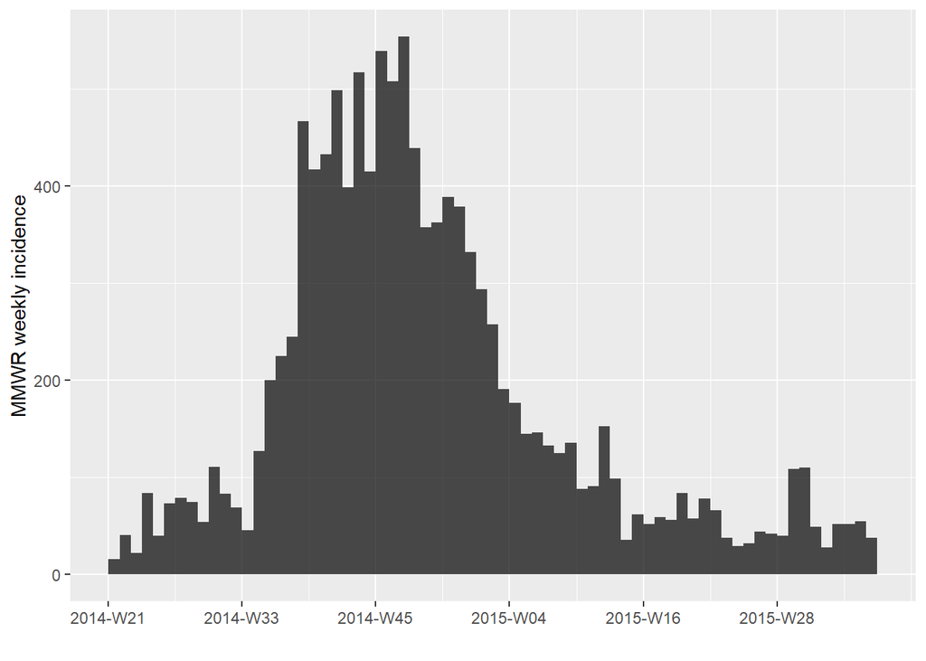

```r
wk_inc_epi = incidence(Ebola_SL$date_of_onset, interval="1 epiweek")

plot(wk_inc_epi)
```

Now we calculate weekly incidence by groups, using our `district` variable. Then we plot again using `plot()` and pass a custom pallet through the `col_pal=` argument, as an example.

Click [here](https://sjspielman.github.io/introverse/articles/color_fill_scales.html) for more details on the `colorbrewer` package and different color pallet options.

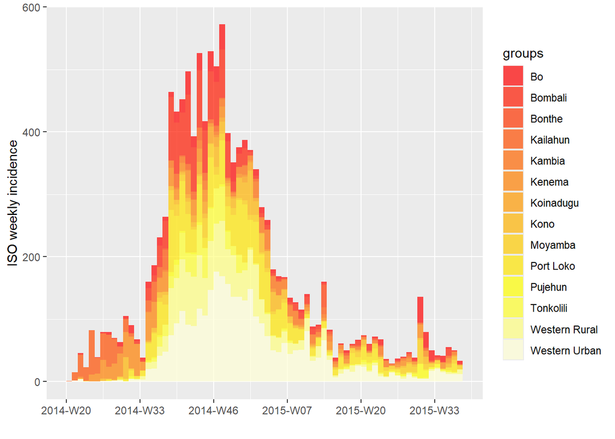

```r
wk_inc_dist = incidence(Ebola_SL$date_of_onset, interval=7, groups=Ebola_SL$district)

plot(wk_inc_dist, col_pal = heat.colors)
```

```r
#A manual color scale can also be provided using the `color` argument as in the code below
#plot(wk_inc_dist, color = c("#ac3973", "#6666ff","purple3","white"....)) #must add colors equal to the number of groups

#library(RColorBrewer)
#colorbrewer pallets can also be used with the code below. More details in link above
#plot(wk_inc_dist)+scale_fill_viridis_d(option="inferno")
```

### `as.incidence()` Converting incidence objects to data frames and back

Below we turn the weekly incidence by districts incidence object, into a data frame with `as.data.frame()`. Data frames can be useful to more easily view and/or modify information in the incidence object.

```r
df_wk_inc_dist = as.data.frame(wk_inc_dist)

head(df_wk_inc_dist)
```

```
##        dates    weeks isoweeks Bo Bombali Bonthe Kailahun Kambia Kenema
## 1 2014-05-12 2014-W20 2014-W20  0       0      0        1      0      0
## 2 2014-05-19 2014-W21 2014-W21  0       0      0       13      0      0
## 3 2014-05-26 2014-W22 2014-W22  2       1      0       35      1      2
## 4 2014-06-02 2014-W23 2014-W23  0       0      0       22      0      0
## 5 2014-06-09 2014-W24 2014-W24  0       0      0       71      0     11
## 6 2014-06-16 2014-W25 2014-W25  1       0      0       25      0     13
##   Koinadugu Kono Moyamba Port Loko Pujehun Tonkolili Western Rural
## 1         0    0       0         0       0         0             0
## 2         0    0       0         0       0         0             0
## 3         0    0       0         1       0         0             0
## 4         0    0       0         1       0         0             0
## 5         0    0       0         0       0         0             0
## 6         0    0       0         0       0         0             0
##   Western Urban
## 1             0
## 2             2
## 3             4
## 4             0
## 5             0
## 6             0
```

Using `as.incidence()` we then turn the data frame back into an incidence object and check for it to be identical to our original `wk_inc_dist` incidence object.

*Note: Remember to set `interval=` equal to the interval that was originally used to create the incidence object. In this case `7`*

```r
#Convert to a matrix and remove date columns, leaving only counts per group columns
matrix_wk_inc_dist <- as.matrix(df_wk_inc_dist[, -c(1:3)])
#Use as.incidence() to turn back into an incidence object
new_wk_inc_dist = as.incidence(matrix_wk_inc_dist,dates = df_wk_inc_dist$dates, interval = 7)

#Check that old and new incidence object are identical
identical(wk_inc_dist,new_wk_inc_dist)
```

```
## [1] TRUE
```

### Aggregated data with `as.incidence()`

Now we’ll use COVID 2020-2021 Michigan data from the CDC. Link to data [here](https://data.cdc.gov/Public-Health-Surveillance/Weekly-Rates-of-Laboratory-Confirmed-COVID-19-Hosp/6jg4-xsqq/about_data). This data comes aggregated by weekly incidence and using the `as.incidence()` function we can turn it into an incidence object.

```r
COVID_20_21 = read.csv("data/COVID_Hosp_20_21_3Age_Groups.csv")
# Picking just Michigan state data
COVID_20_21 = COVID_20_21[COVID_20_21$State=="MI",c(3,4,8)]
head(COVID_20_21)
```

```
##     Week.ending.date Age.Category Weekly.Rate
## 209       2021-10-09    1-4 years         1.9
## 210       2021-10-16    1-4 years         1.9
## 211       2021-10-23    1-4 years         0.0
## 212       2021-10-30    1-4 years         1.9
## 213       2021-11-06    1-4 years         1.9
## 214       2021-11-13    1-4 years         1.9
```

Notice that the weekly rate is numeric, allowing for fractions. This needs to be turned into an integer to prevent a disparity error in the length of dates and counts. Format must also be changed to wide for `as.incidence()` to work properly.

```r
#Rounding and converting counts data to integer
COVID_20_21$Weekly.Rate = as.integer(round(COVID_20_21$Weekly.Rate,0))
#Converting to wide format
library(tidyr)
COVID_20_21 <- pivot_wider(
  data = COVID_20_21,
  names_from = Age.Category,   # Column whose values become new column names
  values_from = Weekly.Rate      # Column whose values fill the new columns
)
head(COVID_20_21)
```

```
## # A tibble: 6 × 4
##   Week.ending.date `1-4 years` `30-39 years` `≥75 years`
##   <chr>                  <int>         <int>       <int>
## 1 2021-10-09                 2            11          41
## 2 2021-10-16                 2            10          53
## 3 2021-10-23                 0             4          51
## 4 2021-10-30                 2             7          50
## 5 2021-11-06                 2             8          74
## 6 2021-11-13                 2            10          79
```

The `as.incidence()` arguments we will use are:

1. Matrix of counts, with time intervals in rows and groups in columns
2. Dates vector corresponding to the row time intervals of the matrix
3. Interval to indicate the time interval used to calculate incidences (1 epiweek in this case)

Once our data frame is turned into an incidence object, we will plot it again using `plot()`

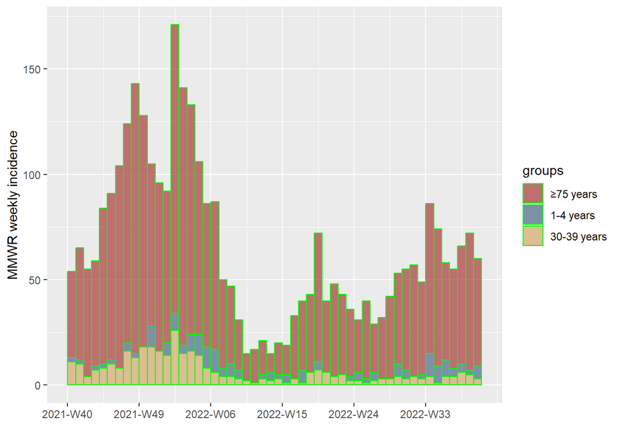

```r
#Convert to a matrix and remove the date column
Matrix_COVID_20_21 <- as.matrix(COVID_20_21[, -1])
#Convert to an incidence object
inc_COVID_20_21 = as.incidence(Matrix_COVID_20_21,dates = COVID_20_21$Week.ending.date, interval = "1 epiweek")
#Plotting with incidence package
plot(inc_COVID_20_21, border = "green") #example of how border colors can be added
```

Now we will turn our incidence object `inc_COVID_20_21` back into a data frame to show that the data remains the same

Notice that the only difference is that incidence adds a weeks column and sets the date as the beginning of the week instead of the end of week (which is what we had in the original data).

```r
new_COVID_20_21 = as.data.frame(inc_COVID_20_21)

head(new_COVID_20_21)
```

```
##        dates    weeks ≥75 years 1-4 years 30-39 years
## 1 2021-10-03 2021-W40        41         2          11
## 2 2021-10-10 2021-W41        53         2          10
## 3 2021-10-17 2021-W42        51         0           4
## 4 2021-10-24 2021-W43        50         2           7
## 5 2021-10-31 2021-W44        74         2           8
## 6 2021-11-07 2021-W45        79         2          10
```

## ggplot2 customizing Incidence plots

Using `ggplot2`, many arguments can be added to the `plot()` function with `+` to customize incidence plots. In this section we will show the use of:

- `scale_x_date()` : controlling how date values on the x-axis are displayed
- `labs()`: sets labels for titles and other plot components
- `theme()` : enables customization of plot aesthetics
- `subset()` : Extracting and displaying specific date ranges of the data

### scale_x_date()

We first show the use of `scale_x_date()` and options for the `breaks=` and `labels=` arguments. Notice how the x-axis date label changes from epiweeks (ex. “2021-W40”) to the specified date format (ex. “03 Oct 2021”). More on date and time R format codes [here](https://stat.ethz.ch/R-manual/R-devel/library/base/html/strptime.html)

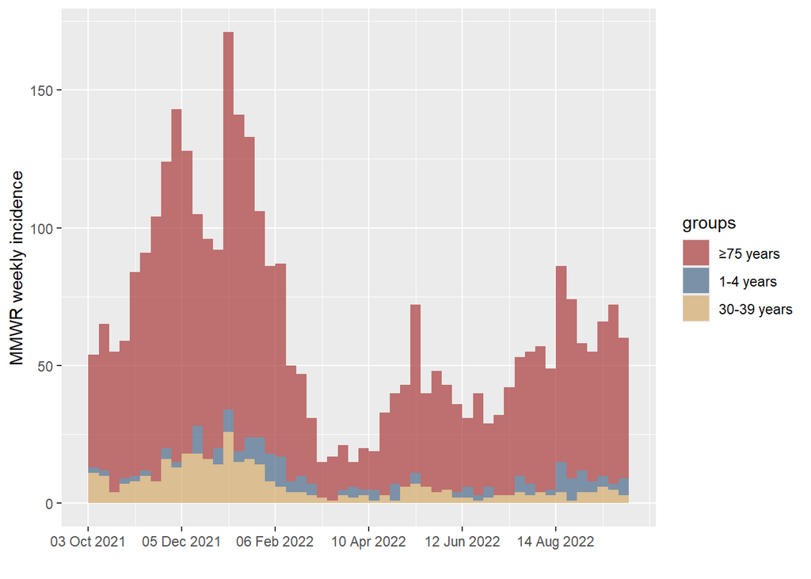

```r
library(ggplot2)

#make_breaks() calculates breaks for the plot, which match brakes used by plot() from the incidence package. These are epiweeks, here labeled as the Sunday beginning of the week
breaks=make_breaks(inc_COVID_20_21)

plot(inc_COVID_20_21) +
   scale_x_date(breaks= breaks$breaks, #we use the "$breaks" element from the "breaks" list
                date_labels="%d %b %Y") #Here we specify in what date format the breaks will be labeled
```

### labs() and theme()

`labs()` (`title=` for the plot title and `fill=` for the legend title) is used to add titles.

`theme()` modifies aesthetics. The `axis.text.x=` argument is used to change the format of dates text on the x-axis, `legend` arguments modify the legend, and the `plot.title=` argument modifies aesthetics of the plot title. A list of many other aesthetic modifications that can be done with theme, can be found [here](https://ggplot2.tidyverse.org/reference/theme.html).

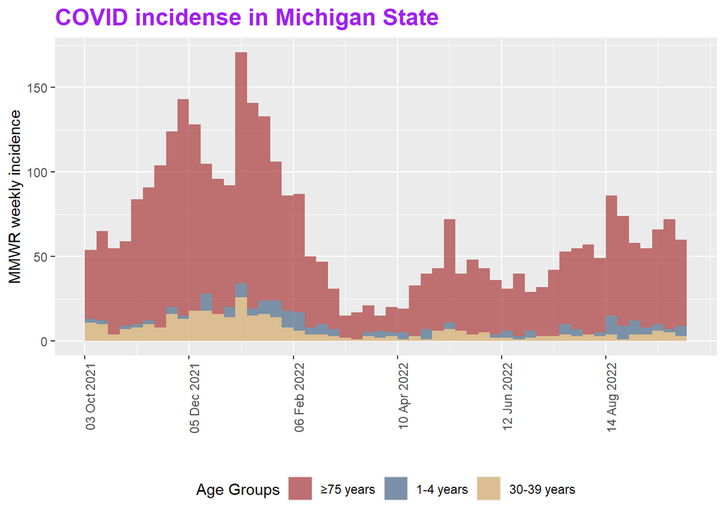

```r
plot(inc_COVID_20_21) +
   scale_x_date(breaks= breaks$breaks,
                date_labels="%d %b %Y") +
  labs(title="COVID incidense in Michigan State",fill="Age Groups")+ #plot and legend title
  theme(axis.text.x = element_text(angle = 90, hjust = 1), #modifies x axis text
          legend.position = "bottom", legend.direction = "horizontal", #modifies legend
        plot.title=element_text(size=16,face="bold",color="purple")) #modifies plot title
```

### subset()

With `subset()` we can extract data for specific date ranges of interest and display a zoomed in group of that weekly incidence.

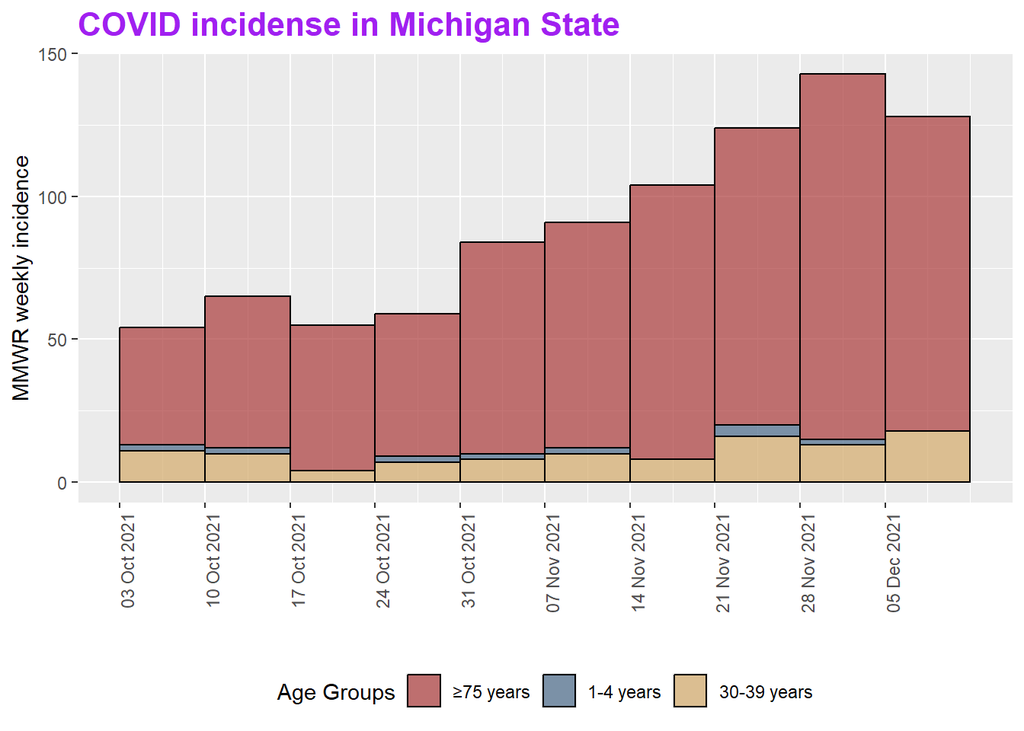

```r
sub_inc_COVID_20_21 = subset(inc_COVID_20_21, from=as.Date("2021-10-03"), to=as.Date("2021-12-05")) #provide the date ranges to extract
sub_breaks= make_breaks(sub_inc_COVID_20_21, n_breaks=nrow(sub_inc_COVID_20_21)) #Calculate new bin breaks for new subset of data. In this case we choose to have a label for every bin.

plot(sub_inc_COVID_20_21, border="black") + #black border added. "show_cases=TRUE" argument can also be added when there are few cases that you want individually outlined
   scale_x_date(breaks= sub_breaks$breaks,
                date_labels="%d %b %Y") +
  labs(title="COVID incidense in Michigan State",fill="Age Groups")+
  theme(axis.text.x = element_text(angle = 90, hjust = 1),
          legend.position = "bottom", legend.direction = "horizontal",
        plot.title=element_text(size=16,face="bold",color="purple"))
```

## Making incidence plots with just ggplot2

`ggplot2` allows for more flexibility and customization in building incidence and prevalence plots, but requires more code and understanding of all the individual components of a ggplot plot. Incidence must be manually aggregated and x-axis dates need to be adjusted as desired and so they align with bins.

### Non-aggregated data

Recall the weekly incidence by districts we calculated previously, using the **Ebola outbreak in Sierra Leone, 2014** data set:

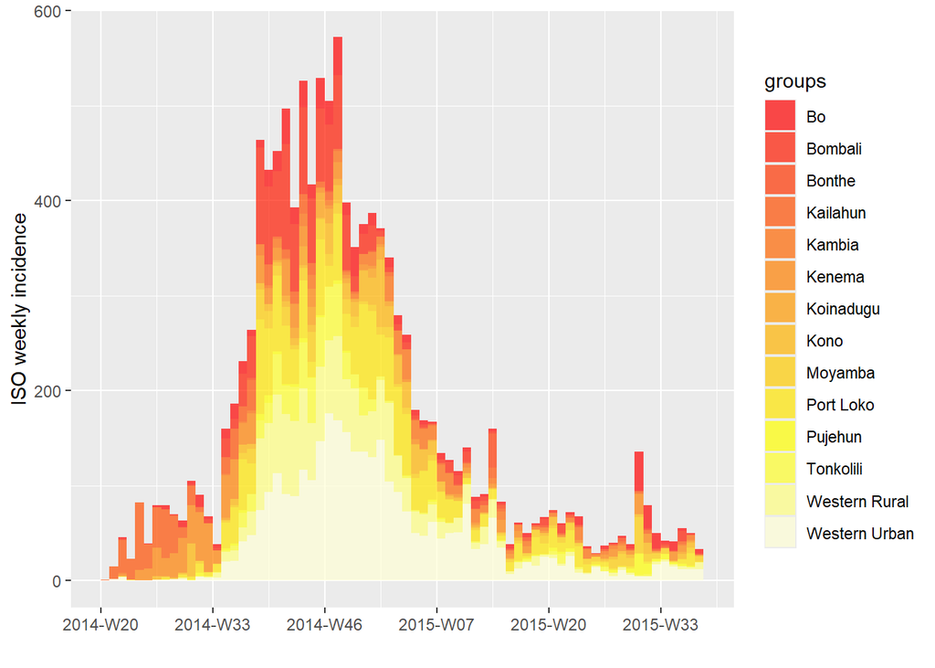

```r
wk_inc_dist = incidence(Ebola_SL$date_of_onset, interval=7, groups=Ebola_SL$district)

plot(wk_inc_dist, col_pal = heat.colors)
```

The data looks like this:

```r
head(Ebola_SL)
```

```
##   id age sex    status date_of_onset date_of_sample district    chiefdom
## 1  1  20   F confirmed    2014-05-18     2014-05-23 Kailahun  Kissi Teng
## 2  2  42   F confirmed    2014-05-20     2014-05-25 Kailahun  Kissi Teng
## 3  3  45   F confirmed    2014-05-20     2014-05-25 Kailahun Kissi Tonge
## 4  4  15   F confirmed    2014-05-21     2014-05-26 Kailahun  Kissi Teng
## 5  5  19   F confirmed    2014-05-21     2014-05-26 Kailahun  Kissi Teng
## 6  6  55   F confirmed    2014-05-21     2014-05-26 Kailahun  Kissi Teng
```

Below we’ll use the non-aggregated data set of **Ebola outbreak in Sierra Leone, 2014** and replicate the graph above, but this time using ggplot2 exclusively.

Note that breaks must be defined for histogram bins (using the `breaks=` argument within `geom_histogram()`) and for gridline positions (using the `breaks=` argument within `scale_x_date()`). If using weeks as breaks, be sure to set the start of the week as desired.

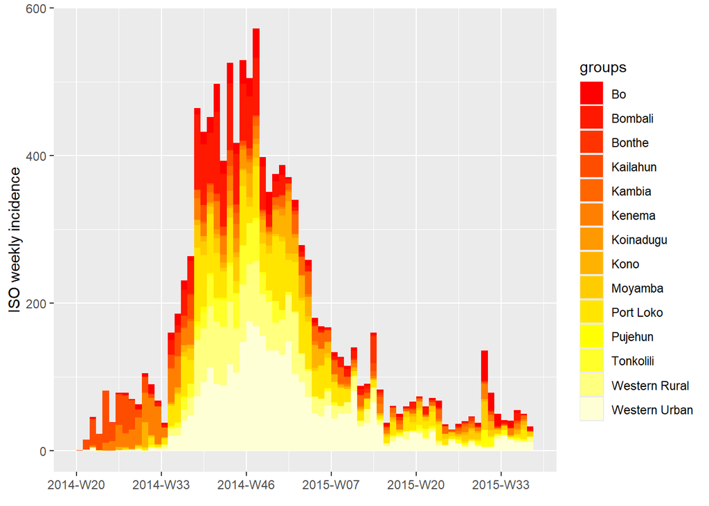

```r
library(lubridate)
# Breaks sequence must be defined to calculate iso weekly incidence
wk_breaks <- seq.Date(
# Monday before first case
from = floor_date(min(Ebola_SL$date_of_onset, na.rm=T),"week",week_start = 1),
# Monday after last case
to=ceiling_date(max(Ebola_SL$date_of_onset, na.rm=T), "week", week_start = 1),
# bins are 7-days each
by   = "week")

#Graphing
ggplot(data = Ebola_SL) +
#date column mapped to x-axis
geom_histogram(mapping = aes(x = date_of_onset,
#grouped by district
fill=district),
#count cases from start of breakpoint bars. Next Monday is counted in the next break. Current Monday in this break
closed = "left",
#histogram defined breaks to aggregate by iso weekly incidence
breaks = wk_breaks)+
#fill palette color for the districts grouping
scale_fill_manual(values=heat.colors(14))+
#Major Gridline breaks. Use same as "wk_breaks", but separated "by" desired gap in major gridlines
scale_x_date(breaks = seq.Date(from=floor_date(min(Ebola_SL$date_of_onset, na.rm=T),"week",week_start =1),to=ceiling_date(max(Ebola_SL$date_of_onset, na.rm=T),"week", week_start = 1),by="13 weeks"),
#labels for major gridlines. In ISO week format
date_labels="%Y-W%V")+
#y, x and legend titles
labs(y= "ISO weekly incidence",x=element_blank(),fill="groups")
```

### Aggregated data

Here we will go back to using our weekly incidence aggregated COVID 2020-2021 Michigan data from the CDC and will replicate the incidence created plot using ggplot2 exclusively.

Below is what the incidence plot looks like

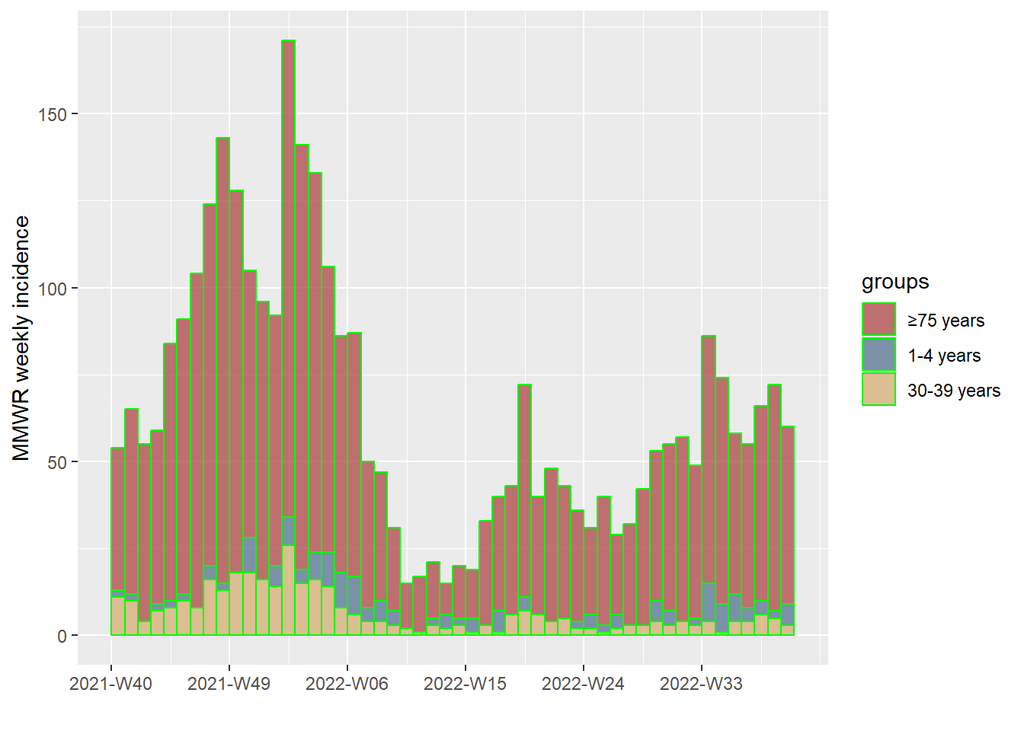

```r
plot(inc_COVID_20_21, border = "green") #example of how border colors can be added
```

This is the same data used to generate the plot above. We will import and prepare it from scratch to then graph solely using ggplot.

```r
COVID_20_21 = read.csv("data/COVID_Hosp_20_21_3Age_Groups.csv")
# Picking just Michigan state data
COVID_20_21 = COVID_20_21[COVID_20_21$State=="MI",c(3,4,8)]
#Rounding and converting counts data to integer
COVID_20_21$Weekly.Rate = as.integer(round(COVID_20_21$Weekly.Rate,0))
#Coverting to date class
COVID_20_21$Week.ending.date = as.Date(COVID_20_21$Week.ending.date)
#Getting epi week start date to match graph above. wday() treats the week as starting on Sunday by default
COVID_20_21$wk_start = COVID_20_21$Week.ending.date-(wday(COVID_20_21$Week.ending.date)-1)
#unaggregating data by adding copies of each row corresponding to its "Weekly.Rate" column. Explained why this is done below in Note: section
COVID_20_21 = COVID_20_21[rep(seq_len(nrow(COVID_20_21)), COVID_20_21$Weekly.Rate), ]

#Sample of data
head(COVID_20_21)
```

```
##       Week.ending.date Age.Category Weekly.Rate   wk_start
## 209         2021-10-09    1-4 years           2 2021-10-03
## 209.1       2021-10-09    1-4 years           2 2021-10-03
## 210         2021-10-16    1-4 years           2 2021-10-10
## 210.1       2021-10-16    1-4 years           2 2021-10-10
## 212         2021-10-30    1-4 years           2 2021-10-24
## 212.1       2021-10-30    1-4 years           2 2021-10-24
```

The main difference when using aggregated data is the use of the `y=` (defining the counts column) and `stat="identity"` (specifying that bar height should be the `y=` value and not the number of rows as is the default) arguments within `histogram()`.

*Note: I found it difficult in ggplot to align gridlines with the start of bins when using aggregated data. Bins are treated as factors with a gridline in their center identifying them, instead the x-axis being continuous time on which the bins are placed. A workaround was to unaggregate the data as done in data prepping above. The line of code to graph aggregated data is commented out below. Feel free to use it if that result is what you’re looking for.*

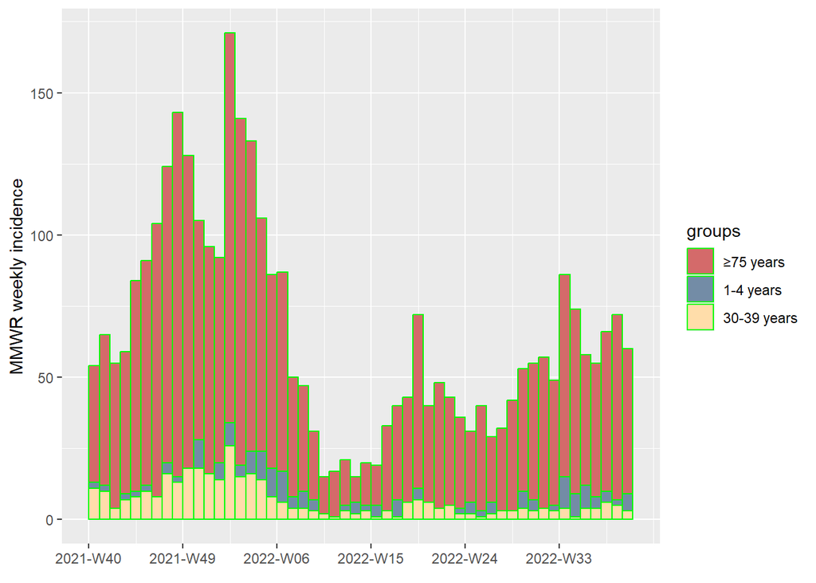

```r
ggplot(COVID_20_21) +
#geom_histogram() with the line below is used for aggregated data. Be sure to change data source above to the aggregated data ex.ggplot(Aggregated_Data)
# geom_histogram(mapping=aes(x=wk_start,y=Weekly.Rate,fill=Age.Category),stat="identity",color="green",
geom_histogram(mapping=aes(x=wk_start,fill=Age.Category),color="green",
breaks=seq.Date(from=floor_date(min(COVID_20_21$wk_start, na.rm=T),"week", week_start = 7), to=ceiling_date(max(COVID_20_21$wk_start, na.rm=T),"week", week_start = 7), by="7 days"),
#Minor breaks can also be added
# minor_breaks = seq.Date(from=floor_date(min(COVID_20_21$wk_start, na.rm=T),"week",week_start=7),to=ceiling_date(max(COVID_20_21$wk_start, na.rm=T),"week",week_start=7),by="7 days"),
closed="left")+
scale_x_date(breaks = seq.Date(from=floor_date(min(COVID_20_21$wk_start, na.rm=T),"week",week_start =7),to=ceiling_date(max(COVID_20_21$wk_start, na.rm=T),"week", week_start = 7),by="9 weeks"), date_labels="%Y-W%U")+
scale_fill_manual(values=incidence_pal1_light(3))+ #one of the default palettes used by incidence when plotting
labs(x=element_blank(),y="MMWR weekly incidence",fill="groups")
```

### Facetted Plots

One other useful thing that can quickly be done with ggplot by adding the `facet_wrap()` function to an existing graph. This allows you to have multiply small graphs for each individual category used to group the data. Furthermore, we add `gghighlight()` from the `gghighlight` package to show the total epidemic in the background of each facet.

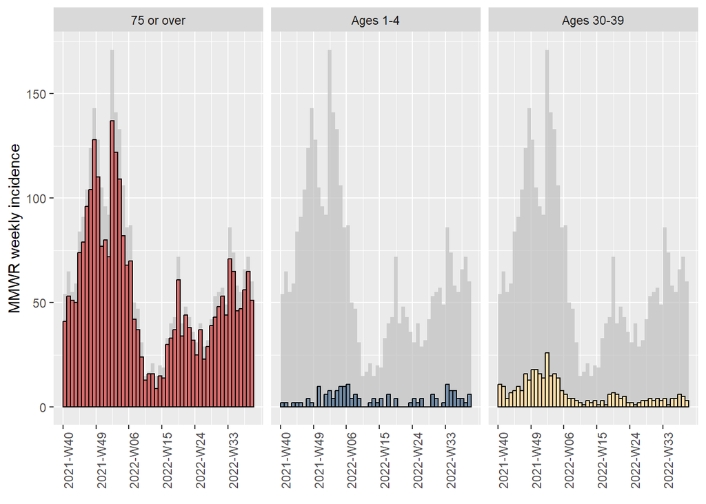

```r
# install.packages("gghighlight")
library(gghighlight)

#Creating facet labels
facet_labels = as_labeller(c("≥75 years"="75 or over","1-4 years"="Ages 1-4","30-39 years"="Ages 30-39"))

ggplot(COVID_20_21) +
geom_histogram(mapping=aes(x=wk_start,fill=Age.Category),color="black",
breaks=seq.Date(from=floor_date(min(COVID_20_21$wk_start, na.rm=T),"week", week_start = 7), to=ceiling_date(max(COVID_20_21$wk_start, na.rm=T),"week", week_start = 7), by="7 days"),
closed="left")+
scale_x_date(breaks = seq.Date(from=floor_date(min(COVID_20_21$wk_start, na.rm=T),"week",week_start =7),to=ceiling_date(max(COVID_20_21$wk_start, na.rm=T),"week", week_start = 7),by="9 weeks"), date_labels="%Y-W%U")+
scale_fill_manual(values=incidence_pal1_light(3))+
labs(x=element_blank(),y="MMWR weekly incidence",fill="groups") +

#Highlight for total epidemic in the background
gghighlight::gghighlight()+
#Add column group to display after "~". Number of columns and rows can be specified, strip position, etc.
facet_wrap(~Age.Category,strip.position="top",nrow=1,ncol=3,labeller=facet_labels)+
theme(axis.text.x = element_text(angle = 90, hjust = 1))
```

## Surveil Package

Surveil is designed for routine time trend analysis such as disease incidence rates or mortality rates. The primary function in surveil is the `stan_rw()` function, which has the option of fitting the Poisson or the Binomial models to surveillance data.

The package also contains special methods for age-standardization, printing and plotting model results, and for measuring and visualizing health inequalities. You can also view functions of risk estimates, such as cumulative percent change.

Below is a quick summary of the package as shown online. More examples and vignettes on the package can be found [here](https://connordonegan.github.io/surveil/).

```r
library(surveil)

#View sample data in surveil package
head(msa)
```

```
## # A tibble: 6 × 5
##    Year Race                      MSA                   Count Population
##   <int> <chr>                     <chr>                 <dbl>      <dbl>
## 1  1999 Black or African American Austin-Round Rock, TX    28      14421
## 2  2000 Black or African American Austin-Round Rock, TX    16      15215
## 3  2001 Black or African American Austin-Round Rock, TX    22      16000
## 4  2002 Black or African American Austin-Round Rock, TX    24      16694
## 5  2003 Black or African American Austin-Round Rock, TX    34      17513
## 6  2004 Black or African American Austin-Round Rock, TX    26      18429
```

To analyze incidence by race over time, we combine MSA and aggregate the data. This means adding incidence (`Count`) and population (`Population`) numbers by year and race.

```r
msa2 <- aggregate(cbind(Count, Population) ~ Year + Race, data = msa, FUN = sum)

head(msa2)
```

```
##   Year                      Race Count Population
## 1 1999 Black or African American   471     270430
## 2 2000 Black or African American   455     283280
## 3 2001 Black or African American   505     298287
## 4 2002 Black or African American   539     313133
## 5 2003 Black or African American   546     329481
## 6 2004 Black or African American   602     346886
```

### stan_rw() - Fitting the Model

`stan_rw()` expects a data frame with one column names `Count` (containing case counts) and another column named `Population` (containing the sizes of the populations at risk). User provides the name of the column containing the time period and, optionally, a grouping factor can be provided.

Below the Poisson model is used and fit to the data using `stan_rw()`. `iter=1e3` controls how long the sampling continues for with the defualt being 3,000.

Results can be printed and they are also stored in a summary data frame, showing estimates with 95% credible intervals.

```r
fit <- stan_rw(msa2, time = Year, group = Race, iter = 1e3)
```

```
## [1] "Setting normal prior(s) for eta_1: "
```

```
##  location scale
##        -6     5
## [1] "\nSetting half-normal prior for sigma: "
```

```
##  location scale
##         0     1
##
##
##
##
```

```r
head(fit$summary)
```

```
##   time        mean     lwr_2.5    upr_97.5                      Race Year Count
## 1 1999 0.001714493 0.001591013 0.001853313 Black or African American 1999   471
## 2 2000 0.001653145 0.001501488 0.001773945 Black or African American 2000   455
## 3 2001 0.001685812 0.001575983 0.001809280 Black or African American 2001   505
## 4 2002 0.001699351 0.001594267 0.001833239 Black or African American 2002   539
## 5 2003 0.001706174 0.001559824 0.001799230 Black or African American 2003   546
## 6 2004 0.001703417 0.001582199 0.001845113 Black or African American 2004   602
##   Population       Crude
## 1     270430 0.001741671
## 2     283280 0.001606185
## 3     298287 0.001693000
## 4     313133 0.001721313
## 5     329481 0.001657152
## 6     346886 0.001735440
```

Using `ggplot`, `plot()` will visualize estimates for the three ethnicities with their corresponding 95% intervals. Crude incident rates are plotted as points and `scale=100e3` displays rates per 100,000.

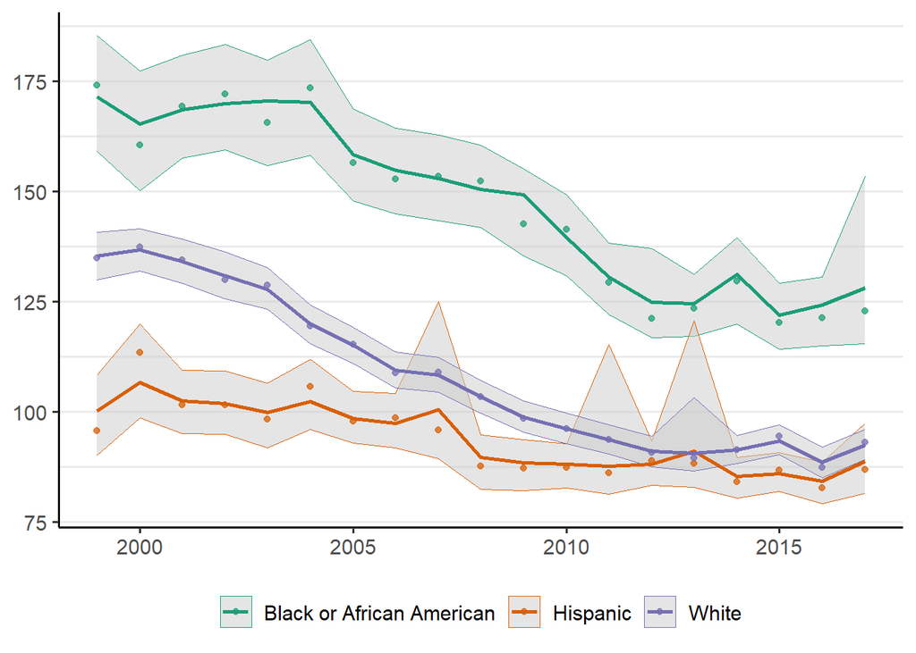

```r
plot(fit, scale=100e3)
```

### apc() - Percent Change

`apc()` calculates percent change by period and cumulatively over time. The object returned contains two data frames. One is contains estimates of percent change from the previous period and the other contains estimates of cumulative percent change since the first observed period.

```r
fit_pc <- apc(fit)

head(fit_pc$cpc)
```

```
##   time                     group        cpc       lwr      upr
## 1 1999 Black or African American  0.0000000   0.00000 0.000000
## 2 2000 Black or African American -3.4531467 -15.62857 5.272482
## 3 2001 Black or African American -1.5359390 -11.22292 7.897016
## 4 2002 Black or African American -0.7425313 -10.27639 8.893728
## 5 2003 Black or African American -0.4682871 -12.22766 8.387209
## 6 2004 Black or African American -0.5521607 -10.37065 9.926549
```

```r
#head(fit_pc$apc) #This plot the first data frame with percent changes by period
```

Again, using `ggplot` through `plot()`, we plot `cpc` results. This is an estimate of the difference in incidence rates between that year and the first year, expressed as a percent of the first year’s rate. We also see the lower and upper bounds of the 95% credible intervals for the estimates.

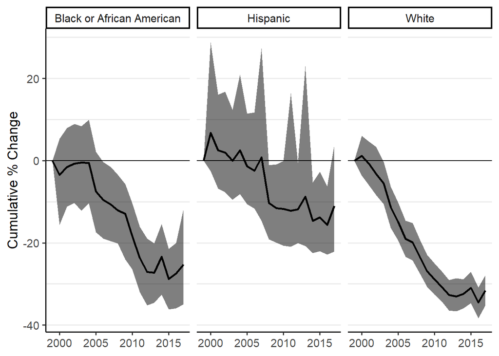

```r
plot(fit_pc, cumulative=TRUE)
```

### ggplot and customizing surveil graphs

The surveil `plot()` function includes some arguments that can be used to customize the graphs. But using `ggplot2`, many arguments can be added to the `plot()` function with `+` to customize the graphs as well. This is just like we did with the plots from the `incidence` package.

`base_size=` controls the size of labels. `style="lines` samples from the join probability distribution for the estimates. The `scale=` can be changed from rates per 100,000

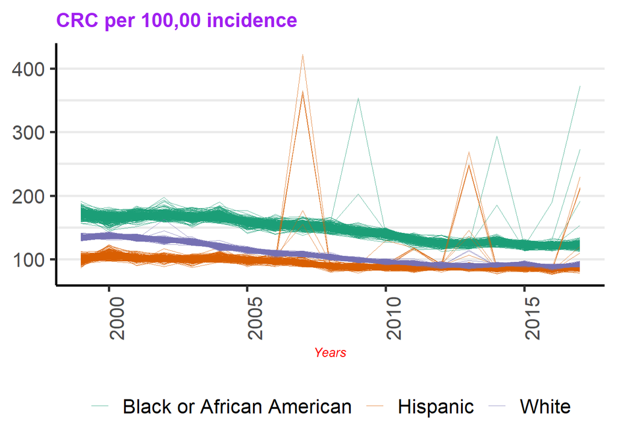

```r
#These are all changes within the `plot` function
plot(fit,scale=100e3,base_size=20,style="lines")+

#All ggplot additions with "+"
labs(title="CRC per 100,00 incidence",x="Years")+ #plot title and x-axis label
theme(axis.text.x = element_text(angle = 90), #modifies x axis text
axis.title= element_text(face="italic",size=10,color="red"), #modifies x-axis label
plot.title=element_text(size=16,face="bold",color="purple")) #modifies plot title
```

## IncidencePrevalence Package

This package contains functions for estimating population-level incidence and prevalence using the OMOP common data model and denominator and outcome cohorts. Below is a summary of the package as shown online. Information that I found and for citations, click [here](https://darwin-eu.github.io/IncidencePrevalence/).

It is designed to work with data in the OMOP CDM format, so we will create a reference to and use data from the `CDMConnector` package

```r
# install.packages("IncidencePrevalence")
library(CDMConnector)
library(IncidencePrevalence)

#loading data
cdm <- mockIncidencePrevalence(
  sampleSize = 10000,
  outPre = 0.3,
  minOutcomeDays = 365,
  maxOutcomeDays = 3650
)

head(cdm)
```

```
## $person
## # Source:   table<person> [?? x 18]
## # Database: DuckDB 1.5.0 [ArenasE@Windows 10 x64:R 4.4.2/:memory:]
##    person_id gender_concept_id year_of_birth month_of_birth day_of_birth
##        <int>             <int>         <int>          <int>        <int>
##  1         1              8532          1962              4            2
##  2         2              8507          1975              2           24
##  3         3              8507          1990              6           19
##  4         4              8507          1993             12           18
##  5         5              8507          1971             12           24
##  6         6              8532          1961              1           25
##  7         7              8532          1970             12           27
##  8         8              8532          1991              4           15
##  9         9              8507          1973              1            2
## 10        10              8507          1949              4           24
## # ℹ more rows
## # ℹ 13 more variables: birth_datetime <date>, race_concept_id <int>,
## #   ethnicity_concept_id <int>, location_id <int>, provider_id <int>,
## #   care_site_id <int>, person_source_value <chr>, gender_source_value <chr>,
## #   gender_source_concept_id <int>, race_source_value <chr>,
## #   race_source_concept_id <int>, ethnicity_source_value <chr>,
## #   ethnicity_source_concept_id <int>
##
## $observation_period
## # Source:   table<observation_period> [?? x 5]
## # Database: DuckDB 1.5.0 [ArenasE@Windows 10 x64:R 4.4.2/:memory:]
##    observation_period_id person_id observation_period_s…¹ observation_period_e…²
##                    <int>     <int> <date>                 <date>
##  1                     1         1 1977-02-07             1985-09-25
##  2                     2         2 1989-09-24             1991-12-05
##  3                     3         3 1988-06-16             1999-03-13
##  4                     4         4 1942-04-24             1942-06-07
##  5                     5         5 1915-05-07             1926-02-17
##  6                     6         6 2008-08-31             2010-07-31
##  7                     7         7 1986-04-25             1988-02-11
##  8                     8         8 1995-07-28             1995-08-10
##  9                     9         9 1929-07-14             1939-09-20
## 10                    10        10 1992-08-30             1994-12-01
## # ℹ more rows
## # ℹ abbreviated names: ¹observation_period_start_date,
```

[output cut: 38 more lines]

```
## # Source:   table<censor> [?? x 4]
## # Database: DuckDB 1.5.0 [ArenasE@Windows 10 x64:R 4.4.2/:memory:]
##    cohort_definition_id subject_id cohort_start_date cohort_end_date
##                   <int>      <int> <date>            <date>
##  1                    1       1815 1900-06-03        1906-11-09
##  2                    1       7414 1975-03-03        1985-06-03
##  3                    1        491 1974-09-28        1982-06-05
##  4                    1       2329 1977-10-29        1982-02-27
##  5                    1        110 1920-07-04        1929-04-19
##  6                    1       7581 1967-11-05        1976-11-05
##  7                    1       3344 1902-01-29        1908-06-22
##  8                    1       4131 1909-01-16        1914-05-10
##  9                    1       3085 1944-01-26        1953-01-24
## 10                    1       7248 1991-07-28        1993-02-24
## # ℹ more rows
```

### Identifying Denominator Cohort

```r
#We identify a denominator cohort
#We get 6 denominator cohorts in the OMOP CDM structure
cdm <- generateDenominatorCohortSet(
  cdm = cdm,
  name = "denominator",
  cohortDateRange = as.Date(c("2008-01-01", "2018-01-01")),
  ageGroup = list(
    c(0, 64),
    c(65, 100)
  ),
  sex = c("Male", "Female", "Both"),
  daysPriorObservation = 180
)

head(cdm$denominator)
```

```
## # Source:   SQL [?? x 4]
## # Database: DuckDB 1.5.0 [ArenasE@Windows 10 x64:R 4.4.2/:memory:]
##   cohort_definition_id subject_id cohort_start_date cohort_end_date
##                  <int>      <int> <date>            <date>
## 1                    1         87 2008-01-01        2018-01-01
## 2                    1        116 2008-01-01        2009-01-10
## 3                    1        204 2008-01-01        2009-12-05
## 4                    1        271 2008-01-01        2008-02-06
## 5                    1        371 2008-01-01        2011-04-23
## 6                    1        390 2010-04-14        2013-03-29
```

### Outcome Cohort

Mock data already has an outcome cohort that has been identified

```r
head(cdm$outcome)
```

```
## # Source:   SQL [?? x 4]
## # Database: DuckDB 1.5.0 [ArenasE@Windows 10 x64:R 4.4.2/:memory:]
##   cohort_definition_id subject_id cohort_start_date cohort_end_date
##                  <int>      <int> <date>            <date>
## 1                    1          2 1991-07-21        1991-12-05
## 2                    1          3 1996-08-23        1999-03-13
## 3                    1          9 1934-05-01        1939-09-20
## 4                    1         10 1994-06-16        1994-12-01
## 5                    1         13 1963-01-20        1969-02-06
## 6                    1         15 1901-01-28        1904-08-02
```

### Estimating Incidence

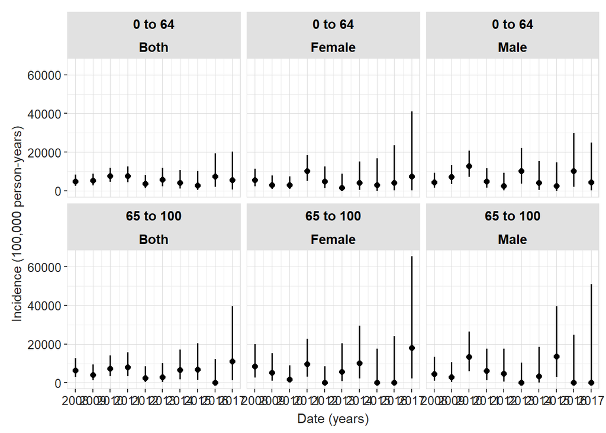

```r
inc <- estimateIncidence(
  cdm = cdm,
  denominatorTable = "denominator",
  outcomeTable = "outcome",
  interval = "years",
  repeatedEvents = TRUE,
  outcomeWashout = 180,
  completeDatabaseIntervals = TRUE
)
plotIncidence(inc, facet = c("denominator_age_group", "denominator_sex"))
```